```python
import librosa
import numpy as np
import pandas as pd
import matplotlib.pyplot as plt
import scipy.stats as stats
from PIL import Image
from matplotlib.image import imread
import math
import scipy
import sys
import random
import copy
#np.set_printoptions(threshold=1000)
```

# Question 1

```python
data = np.array([[20,25,18,15,28], #blue berries
                 [1,0,2,1,1], #peanut butter
                 [10,12,8,15,5] #yogurt
                ])

Total = np.sum(data)
```

4)

```python
Probab_blueberries = np.sum(data[0,:])/Total
Probab_butter = np.sum(data[1,:])/Total
Probab_yogurt = np.sum(data[2,:])/Total
```

```python
print(f'Maximum Likelihood')
print(f'Probablity of Blueberries = {Probab_blueberries}')
print(f'Probablity of Peanut Butter = {Probab_butter}')
print(f'Probablity of Yogurt = {Probab_butter}')
```

```
Maximum Likelihood
Probablity of Blueberries = 0.6583850931677019
Probablity of Peanut Butter = 0.031055900621118012
Probablity of Yogurt = 0.031055900621118012
```

**Maximum Likelihood** $P_{blueberries = }\frac{\sum Blueberries}{Total} \\ P_{peanut_butter = }\frac{\sum Peanut_Butter}{Total} \\ P_{Yogurt = }\frac{\sum Yogurt}{Total} $

8)

```python
Prior_blue_berry = 330
Prior_peanut_butter = 29
Prior_yogurt = 310
```

```python
Total_prior = Prior_blue_berry+Prior_peanut_butter+Prior_yogurt
```

```python
MAP_Prob_blueberries = (np.sum(data[0,:])+ Prior_blue_berry)/(Total+Total_prior)
MAP_Prob_butter = (np.sum(data[1,:])+ Prior_peanut_butter)/(Total+Total_prior)
MAP_Prob_yogurt = (np.sum(data[2,:])+ Prior_yogurt)/(Total+Total_prior)
```

```python
print(f'MAP Estimation')
print(f'MAP of Blueberries = {MAP_Prob_blueberries}')
print(f'MAP of Peanut Butter = {MAP_Prob_butter}')
print(f'MAP of Yogurt = {MAP_Prob_yogurt}')
```

```
MAP Estimation
MAP of Blueberries = 0.5253012048192771
MAP of Peanut Butter = 0.04096385542168675
MAP of Yogurt = 0.43373493975903615
```

**MAP Estimation** $P_{MAPblueberries = }\frac{\sum Blueberries + Blueberries Prior}{Total + Total Prior} \\ P_{MAPButter = }\frac{\sum PeanutButter + Peanut Butter Prior}{Total + Total Prior} \\ P_{MAPYogurt = }\frac{\sum Yogurt + Yogurt Prior}{Total + Total Prior}$

# Question 2

```python
x1, sr = librosa.load("x1.wav", sr=None)
x2, sr2 = librosa.load("x2.wav", sr=None)
s1, sr1 = librosa.load("s.wav", sr=None)
```

### Kurtosis and standardization

```python
def standardization(x):
    return (x- np.mean(x))/np.std(x)

def kurtosis(x):
    return np.mean(np.power(standardization(x), 4))-3
```

```python
x1_stand = standardization(x1)
x2_stand = standardization(x2)
s1_stand = standardization(s1)
```

```python
x1_kurtosis = kurtosis(x1)
x2_kurtosis = kurtosis(x2)
s1_kurtosis = kurtosis(s1)

print(f'x1 kurtosis {x1_kurtosis}, x2 kurtosis {x2_kurtosis}, s1_kurtosis {s1_kurtosis}')
```

```
x1 kurtosis 4.907141208648682, x2 kurtosis 3.8733277320861816, s1_kurtosis 7.293442726135254
```

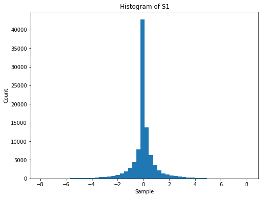

```python
plt.figure(figsize=[8,6]);
plt.hist(s1_stand, bins = 50)
plt.ylabel('Count');
plt.xlabel('Sample');
plt.title('Histogram of S1');
```

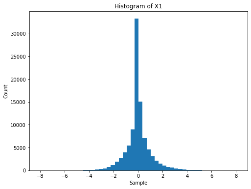

```python
plt.figure(figsize=[8,6]);
plt.hist(x1_stand, bins = 50)
plt.ylabel('Count');
plt.xlabel('Sample');
plt.title('Histogram of X1');
```

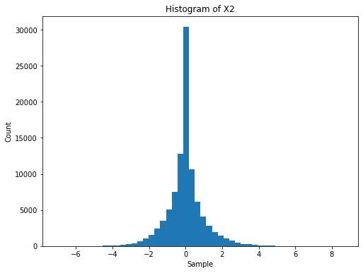

```python
plt.figure(figsize=[8,6]);
plt.hist(x2_stand, bins = 50)
plt.ylabel('Count');
plt.xlabel('Sample');
plt.title('Histogram of X2');
```

Seeing the above histogram and kurtosis value of s.wav we can say that it is not a gaussian distribution as it very spiky as well as the kurtosis value is 7.29 which is quite above 0 (as we are calculating excess kurtosis).

Out of x1.wav and x2.wav, x2.wav kurtosis value is less than x1.wav and also somewhat closer to zero. Even though we can't say that any of the distribution is a gaussian, x2.wav is closer to to be a gaussian compared to x1.wav. As x2.wav is more gaussian like it has more noise compared to x1.wav

# Question 3

## Gradient Descent

1. Load sg train.jpg. This is the clean image you use as the target of the optimization. Load sgx train.jpg, too. It’s the noisy image you use as the input training data. Your test input is sgx test.jpg. Replicate the denoising procedure (including testing) from page 7 to 11 in “Lecture 03 - Optimization.” Show me the denoised images (of both training and testing image).

```python
# Load the data
sg_train  = imread("sg_train.jpg")
sgx_train = imread("sgx_train.jpg")
sgx_test  = imread("sgx_test.jpg")
```

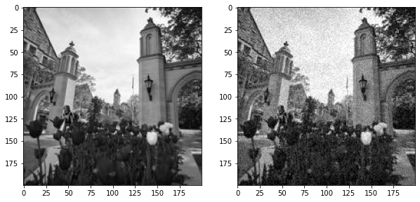

```python
plt.figure(figsize=[10,8]);
plt.subplot(1, 2, 1)
plt.imshow(sg_train,cmap = 'gray')

plt.subplot(1, 2, 2)
plt.imshow(sgx_train,cmap = 'gray')
```

#### Selected 3*3 as a convolution filter

```python
# Initialize a random filter and then flatten it

conv_filter = np.array([[0.1, 0.1, 0.1], [0.1, 0.1, 0.1], [0.1, 0.1, 0.1]])
conv_filter1 = conv_filter.flatten(order='C')
conv_filter1 = conv_filter1.reshape(9,1)
```

#### Creating X_patch which would be of (9,39204) dimension

```python
# Creating X_patch which would be of (9, 39204) dimension

def build_matrix(dat_matrix, conv_filter):
    dat_matrix = dat_matrix/255

    width = len(dat_matrix[0])
    height = len(dat_matrix)

    convolution_matrix = []
    for i in range(0, height - conv_filter.shape[0] + 1):
        for j in range(0, width - conv_filter.shape[0] + 1):
            inner_matrix = []
            for row in range(j, j + conv_filter.shape[0]):
                for col in range(i, i + conv_filter.shape[1]):
                    inner_matrix.append(dat_matrix[col][row])
            convolution_matrix.append(inner_matrix)

    convolution_matrix_1 = np.array(convolution_matrix)

    convolution_matrix_transpose = convolution_matrix_1.transpose()
    return convolution_matrix_transpose

# store the value in the convolution_matrix
convolution_matrix = build_matrix(sgx_train, conv_filter)

# check the shape of convolution_matrix
convolution_matrix.shape
```

```
(9, 39204)
```

#### Check whether convolution matrix is fine

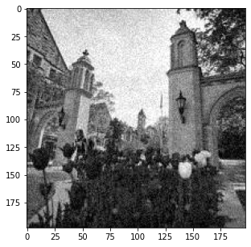

```python
plt.figure(figsize=[6,5]);
plt.imshow(convolution_matrix[4,:].reshape(198,198),cmap = 'gray')
```

#### Normalize the clean image and flatten the sg_train image

```python
sg_train  = sg_train/255
sg_train1 = sg_train[1:199,1:199]
sg_train2 = sg_train1.flatten(order='C').reshape(-1,1)
```

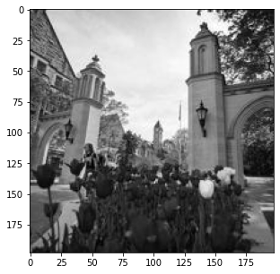

```python
plt.figure(figsize=[6,5]);
plt.imshow(sg_train2.reshape(198,198),cmap = 'gray')
```

#### Creating log and derivative function

```python
def log_function(x):
    return 1/(1+np.exp(-x))

def log_derivative(x):
    return log_function(x)*(1- log_function(x))
```

#### Computing Gradient descent

We are going to use below formula to update our filter so that we can reach the local minima

$\partial E/\partial f= -2X{(s^T- g(f^TX)) \odot {g}'(f^TX)}/N$

$\Delta f(i) = -\partial E/\partial f(i)$

$f(i+1) <-f(i) +\alpha \Delta f(i)$

```python
# iterating over 20000 times

mse = []
for i in range(0,20000):
    FX = np.dot(conv_filter1.T, convolution_matrix)

    # log function and derivative of it
    log_array = log_function(FX)
    log_der_array = log_derivative(FX)

    # calculation S - g(FX)
    Error = sg_train2.T- log_array

    #calculate mean squared error
    mse1 = np.mean(np.square(Error))
    mse.append(mse1)

    #multiply by first derivative
    Error_derv= np.multiply(Error,log_der_array)

    # calculation of dE/df
    dE_dF = -2*np.dot(convolution_matrix, Error_derv.T)/(198*98)

    # at 0.1 learning rate
    conv_filter1 = conv_filter1 - 0.1*dE_dF
```

#### After applying the filter our train image looks like

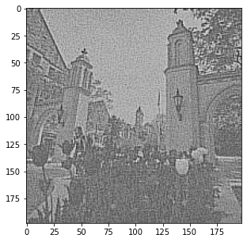

```python
plt.figure(figsize=[6,5]);
plt.imshow(np.array(log_array).reshape(198,198),cmap = 'gray')
```

#### Mean Squared Error plot in each iteration

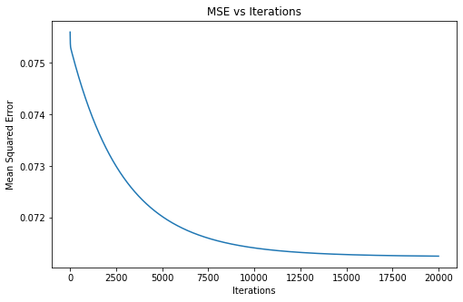

```python
iteration = np.arange(0, 20000)
plt.figure(figsize=[8,5]);
plt.plot(iteration, np.array(mse))
plt.ylabel('Mean Squared Error');
plt.xlabel('Iterations');
plt.title('MSE vs Iterations');
plt.show()
```

#### Applying the filter which we got from gradient descent to the test image

```python
convolution_matrix_test = build_matrix(sgx_test, conv_filter)
FX1 = np.dot(conv_filter1.T, convolution_matrix_test)
log_array_test = log_function(FX1)
```

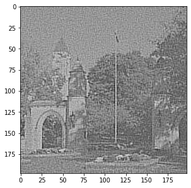

```python
plt.figure(figsize=[6,5]);
plt.imshow(np.array(log_array_test).reshape(198,198),cmap = 'gray')
```

## BFGS Approach

We are going to use Quasi newton approach to get our filter

We are going to start with an identity matrix and and 3*3 filter

```python
# start with an identity matrix
G = 0.1*np.identity(9)

# Initialize a random filter
conv_filter = np.array([[0.1, 0.1, 0.1], [0.1, 0.1, 0.1], [0.1, 0.1, 0.1]])

#flaten the filter
conv_filter1 = conv_filter.flatten(order='C')
conv_filter1 = conv_filter1.reshape(9,1)
conv_filter2 = conv_filter1
```

```python
# store the value in the convolution_matrix
convolution_matrix = build_matrix(sgx_train, conv_filter)
```

```python
# import and flatten the image
sg_train1  = imread("sg_train.jpg")
sg_train1 = sg_train1[1:199,1:199]/255
sg_train2 = sg_train1.flatten(order='C').reshape(-1,1)
```

#### For calculating the hessian matrix we need to calculate v,p,u and G from the below functions

```python
def v_calculation(itr):
    if itr == 0:
        pass
    else:
        return(del_f[itr] - del_f[itr-1])

def p_calculation (itr):
    if itr == 0:
        pass
    else:
        return(filter_upd[itr] - filter_upd[itr-1])


def u_calculation (itr,v,p,G):
    if itr == 0:
        pass
    else:
        return(p/np.dot(p.T,v) - np.dot(G,v)/np.dot(np.dot(v.T,G),v))


def g_calculation (itr,v,p,u,G):
    if itr == 0:
        return(0.1*np.identity(9))
    else:
        return(G + np.dot(p,p.T)/np.dot(p.T,v) - np.dot(np.dot(G,v),np.dot(v.T,G))/np.dot(v.T,np.dot(G,v)) + np.dot(v.T,np.dot(G,v))*np.dot(u, u.T))
```

#### Running the loop for 300 times. Even though it converges very fast

```python
mse_bfgs = []
filter_upd = []
filter_upd.append(conv_filter2)
del_f = []


for i in range(0,300):

    FX = np.dot(conv_filter1.T, convolution_matrix)

    # log function and derivative of it
    log_array = log_function(FX)
    log_der_array = log_derivative(FX)

    # calculation S - g(FX)
    Error = sg_train2.T- log_array

    #calculate mean squared error
    mse1 = np.mean(np.square(Error))
    mse_bfgs.append(mse1)

    #multiply by first derivative
    Error_derv= np.multiply(Error,log_der_array)

    # calculation of dE/df
    dE_dF = -2*np.dot(convolution_matrix, Error_derv.T)/(198*198)
    del_f.append(dE_dF)

    # updating v,p,u and G
    v = v_calculation(i)
    p = p_calculation(i)
    u = u_calculation(i,v,p,G)
    G = g_calculation(i,v,p,u,G)


    conv_filter1 = conv_filter1 - np.dot(G,dE_dF)
    filter_upd.append(conv_filter1)
```

#### Mean Squared Error plot in each iteration

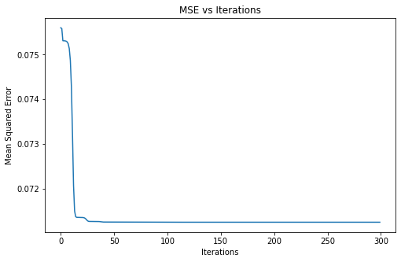

```python
iteration = np.arange(0, 300)
plt.figure(figsize=[8,5]);
plt.plot(iteration, np.array(mse_bfgs))
plt.ylabel('Mean Squared Error');
plt.xlabel('Iterations');
plt.title('MSE vs Iterations');
plt.show()
```

#### Applying the updated filter from BFGS to our image

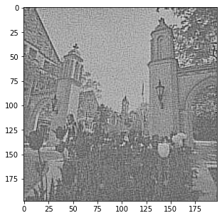

```python
plt.figure(figsize=[6,5]);
plt.imshow(np.array(log_array).reshape(198,198),cmap = 'gray')
```

#### Applying the filter which we got from BFGS to the test image

```python
# for the test image
convolution_matrix_test = build_matrix(sgx_test, conv_filter)

FX1 = np.dot(conv_filter1.T, convolution_matrix_test)
log_array_test = log_function(FX1)
```

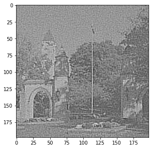

```python
plt.figure(figsize=[6,5]);
plt.imshow(np.array(log_array_test).reshape(198,198),cmap = 'gray')
```

**3. Compare the convergence behavior of the two approaches in graphs.**

The difference between gradient descent and BFGS is that BFGS takes very less iteration to converge where as gradient descent converges slowly and takes more number of iteration.

# Question 4

#### Loading the data

```python
x, sr = librosa.load("x.wav", sr=None)
```

Point 5: First off, create a DFT matrix F using the equation shown in M02-L01-S11 and S12. You’ll of course create a N × N complex matrix, but if you see its real and imaginary versions separately, you’ll see something like the ones in M02-L01-S14 (the ones in the slide are 20×20, i.e. N = 20). For this problem let’s fix N = 1024.

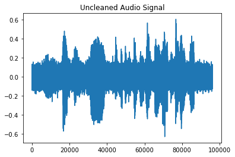

```python
plt.plot(x)
plt.title('Uncleaned Audio Signal')
```

#### Creating a DFT matrix

```python
def DFT_mat(N):
    Mat = np.empty((N,N), dtype = complex)
    for n in range(0,N):
        for f in range(0,N):
            Mat[n][f] = np.exp(-1j*(2*np.pi*n*f/N))
    return Mat
```

```python
N = 1024
```

#### Real component of DFT matrix

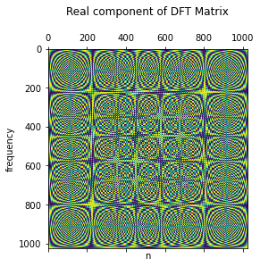

```python
# Real part
DFT =  DFT_mat(N)
plt.figure(figsize=[6,5]);
plt.matshow(DFT.real)
plt.title('Real component of DFT Matrix\n');
plt.xlabel('n');
plt.ylabel('frequency');
plt.show()
```

#### Imaginary component of DFT matrix

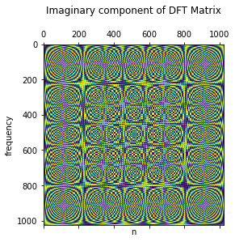

```python
DFT =  DFT_mat(N)
plt.figure(figsize=[6,5]);
plt.matshow(DFT.imag)
plt.title('Imaginary component of DFT Matrix\n');
plt.xlabel('n');
plt.ylabel('frequency');
plt.show()
```

1. Prepare your data matrix X. You extract the first frame of N samples from the input signal, and apply a Hann window2. What that means is that from the definition of Hann window, you create a window of size N and element-wise multiply the window and your N audio samples. Place it as your first column vector of the data matrix X. Move by N/2 samples. Extract another frame of N samples and apply the window. This goes to the second column vector of X. Do it for your third frame (which should start from (N + 1)’th sample, and so on. Since you moved just by the half of the frame size, your frames are overlapping each other by 50%. (Note: this time it’s okay to use the toolbox to calculate Hann windows.)

```python
# Creating X_stack and doing a dot product with DFT
X_stack = []

for i in range(0,  (x.shape[0]//N)*N, N//2):
    X1 = np.multiply(x[i:i+N], scipy.signal.windows.hann(N))
    X_stack.append(X1)

X_stack = np.array(X_stack)
X_stack1 = X_stack.T

# creting Y variable
DFT =  DFT_mat(1024)
Y = np.dot(DFT, X_stack1)
```

```python
Y.shape
```

```
(1024, 186)
```

7.Apply the DFT matrix to your data matrix, i.e. Y = FX. This is your spectrogram with complex values. See how it looks like (by taking magnitudes and plotting).

### Spectogram

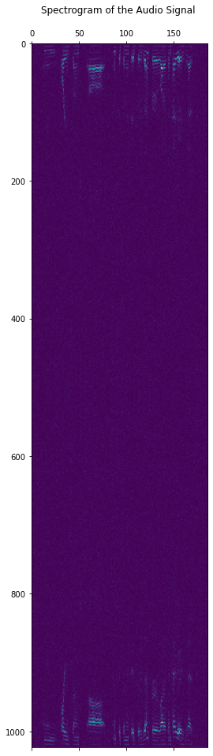

```python
plt.matshow(np.abs(Y), aspect = 'auto')
plt.title('Spectrogram of the Audio Signal \n')
```

We can notice from the spectogram the last column are just noise

1. In this spectrogram, identify frames that are only with noise3. For example the ones at the end of signal would be a good choice. Take a sample mean of the chosen column vectors (the original magnitudes, not the exponentiated ones)

```python
M = np.mean(np.abs(Y[:,-15:-1]), axis = 1).reshape(-1,1)
```

```python
M.shape
```

```
(1024, 1)
```

```python
print(M.min(), M.max())
```

```
0.5270943373413096 1.267480980172502
```

1. Subtract M out of all the magnitude spectra, |Y |. This will give you some residual magnitudes with suppressed noise. Be careful with negative values (by turning them into zeros). Get the original phase from the input spectrogram, i.e. Y /|Y | (element-wise division), and multiply each of the phase values to the corresponding cleaned up magnitude to recover the complex- valued spectra of the estimated clean speech.

```python
# point 9
res_magnitude = np.subtract(np.abs(Y),M)
res_magnitude = np.where(res_magnitude<0, 0, res_magnitude)

phase = np.divide(Y,np.abs(Y))
cleaned_Y = np.multiply(res_magnitude, phase)
```

```python
cleaned_Y.shape
```

```
(1024, 186)
```

#### Creating Inverse DFT matrix

```python
# inverse DFT matrix
def DFT_mat_inv(N):
    Mat = np.empty((N,N), dtype = complex)
    for n in range(0,N):
        for f in range(0,N):
            Mat[n][f] = np.exp(1j*(2*np.pi*n*f/N))
    return Mat/N

# assigning the values of DFT inverse
DFT_inv = DFT_mat_inv(N)
```

#### Real component of DFT Inverse matrix

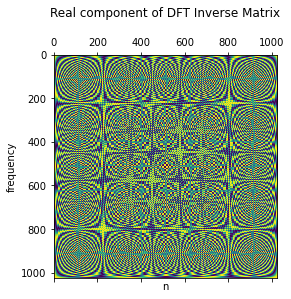

```python
# Real part
plt.figure(figsize=[6,5]);
plt.matshow(DFT_inv.real)
plt.title('Real component of DFT Inverse Matrix\n');
plt.xlabel('n');
plt.ylabel('frequency');
plt.show()
```

#### Imaginary component of DFT Inverse matrix

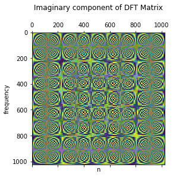

```python
plt.figure(figsize=[6,5]);
plt.matshow(DFT_inv.imag)
plt.title('Imaginary component of DFT Matrix\n');
plt.xlabel('n');
plt.ylabel('frequency');
plt.show()
```

#### check if DFT*DFT_inverse should be identity matrix

```python
Identity_mat = np.dot(DFT_inv, DFT)
print(Identity_mat)
```

```
[[ 1.00000000e+00+0.00000000e+00j -2.70616862e-16-1.71737624e-16j
  -1.04083409e-16-1.73472348e-17j ...  1.47035162e-14+1.14491749e-15j
   1.97758476e-14-2.08166817e-15j  3.99472122e-14-4.54497551e-16j]
 [-2.70616862e-16+1.71737624e-16j  1.00000000e+00+0.00000000e+00j
   1.38777878e-17-1.16226473e-16j ...  9.88098492e-15-2.10248485e-15j
   1.36557432e-14+9.57567359e-16j  2.04072870e-14-8.36136715e-16j]
 [-1.04083409e-16+1.73472348e-17j  1.38777878e-17+1.16226473e-16j
   1.00000000e+00+0.00000000e+00j ...  8.05258638e-15-2.19962937e-15j
   1.06442632e-14-2.27595720e-15j  1.44745327e-14-1.19348975e-15j]
 ...
 [ 2.09832152e-14+1.66533454e-16j  1.66880398e-14+1.99146255e-15j
   1.46549439e-14+3.66373598e-15j ...  1.00000000e+00-8.07487757e-14j
   2.57432964e-14+1.53696500e-15j  1.18932642e-14+2.51534904e-15j]
 [ 5.89250870e-14-6.80011603e-15j  3.18078897e-14-1.51614832e-14j
   4.59424165e-14-4.02455846e-15j ... -6.61137811e-14-2.72698530e-15j
   1.00000000e+00-2.07691503e-13j  6.60305144e-14-1.50573998e-15j]
 [ 6.93889390e-16+3.85282084e-15j -1.08940634e-15+3.34801631e-15j
   9.99200722e-16+2.96290770e-15j ...  1.90264471e-14+2.35575448e-15j
   3.84831056e-14+2.42340870e-15j  1.00000000e+00+1.25448263e-13j]]
```

1. You multipy this matrix to your spectrogram, which is with suppressed white noise, to get back to the recovered version of your data matrix, Xˆ . In theory this should give you a real-valued matrix, but you’ll still see some imaginary parts with a very small value. Ignore them by just taking the real part. Reverse the procedure in 1.6 to get the time domain signal. Basically it must be a procedure that transpose every column vector of Xˆ and overlap-and-add the right half of t-th row vector with the left half of the (t + 1)-th row vector and so on. Listen to the signal to check if the white noise is suppressed.

#### Recovering the Audio signal

```python
# dot product DFT_inv and taking the real part
X_hat = np.dot(DFT_inv,cleaned_Y)
X_hat1 = X_hat.real.T

X_recovered = []
for i in range(0, X_hat1.shape[0]-1):
    if i == 0:
        m = X_hat1[i][0:N//2]
    else:
        m = X_hat1[i-1][N//2:N] + X_hat1[i][0:N//2]
    X_recovered = [*X_recovered,*m]

X_recovered = np.array(X_recovered)
```

```python
print(X_recovered.min(), X_recovered.max())
```

```
-0.5237193239100844 0.42822580380843034
```

```python
X_recovered.shape
```

```
(94720,)
```

[figure not shown]

```python
plt.plot(X_recovered)
plt.title('Uncleaned Audio Signal')
```

```python
X_recovered.shape
```

```
(94720,)
```

#### Uncleaned Audio

```python
import IPython.display as ipd
ipd.Audio('x.wav')
```

[interactive chart not shown]

#### Cleaned Audio

```python
ipd.Audio(X_recovered, rate = sr)
```

[interactive chart not shown]

# Question 5

#### Loading the image

```python
im_left = imread("im0.ppm")
im_right = imread("im8.ppm")
```

```python
im_left.shape
```

```
(381, 430, 3)
```

```python
im_right.shape
```

```
(381, 430, 3)
```

[figure not shown]

```python
fig = plt.figure(figsize = (10,6))

plt.subplot(1, 2, 1)
plt.imshow(im_left)
plt.title('Right Image')

plt.subplot(1, 2, 2)
plt.imshow(im_right)
plt.title('Light Image')
```

```python
im_left.shape
```

```
(381, 430, 3)
```

1. im0.ppm (left) and im8.ppm (right) are the pictures taken by two different camera positions4. If you load the images, they will be a three dimensional array of 381 × 430 × 3, whose third dimension is for the three color channels (RGB). Let’s call them XL and XR. For the (i,j)-th pixel in the right image, XR , which is a 3-d vector of RGB intensities, we can scan and find the most similar pixel in the left image at i-th row (using a metric of your choice). For example, I did the search from XL to XL , to see which pixel among the 40 are(i,j,:) (i,j +39,:)the closest. I record the index-distance of the closest pixel. Let’s say that XL is the (i,j +19,:)most similar one to XR . Then, the index-distance is 19. I record this index-distance (to (i,j,:) the closest pixel in the left image) for all pixels in my right image to create a matrix called “disparity map”, D, whose (i, j)-th element says the index-distance between the (i, j)-th pixel of the right image and its closest pixel in the left image. For an object in the right image (e.g. the tree), if its pixels are associated with an object in the left image, but are shifted far away, that means the object is close to the cameras, and vice versa.

#### Calculating Disparity matrix

```python
Dis_mat = np.ones((im_left.shape[0],im_left.shape[1]-40))

for height in range(0,im_left.shape[0]):
    for width in range(0,im_left.shape[1]-40):
        #initialize some random value to calculate the minimum
        cost_int = im_left.shape[0]*1000

        for x in range(0,40):
            cost_fun = np.mean(np.square(im_right[height,width] - im_left[height,width+x]))
            if cost_fun < cost_int:
                cost_int = cost_fun
                Dis_mat[height,width] = x
```

```python
Dis_mat
```

```
array([[ 2.,  7.,  0., ...,  1., 12.,  7.],
       [ 9.,  4.,  3., ..., 25.,  5., 10.],
       [ 3.,  8.,  7., ..., 30., 29., 28.],
       ...,
       [16., 27., 13., ..., 37., 39., 26.],
       [31., 35., 18., ..., 33., 31., 33.],
       [26., 25., 24., ..., 27., 32., 33.]])
```

1. Calculate the disparity map D from im0.ppm and im8.ppm, which will be a matrix of 381×390 (since we search within only 40 pixels). Vectorize the disparity matrix and draw a histogram. How many clusters do you see?

#### Vectorizing the matrix

```python
Dis_mat_flat = Dis_mat.flatten(order='C')
Dis_mat_flat = Dis_mat_flat.reshape(-1,1)
```

```python
Dis_mat_flat.shape
```

```
(148590, 1)
```

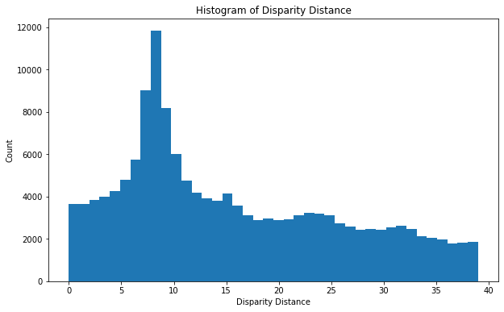

```python
plt.figure(figsize=[10,6]);
plt.hist(Dis_mat_flat, bins = 40)
plt.ylabel('Count');
plt.xlabel('Disparity Distance');
plt.title('Histogram of Disparity Distance');
```

**In the histogram we can notice that there are four gaussian distribution. Hence, we will take the cluster size as 4**

5.Write up your own k-means clustering code, and cluster the disparity values in D. Each value will belong to (only) one of the clusters. The number of clusters says the number of depth levels. For example, in Figure 2, there are only two depths, so k = 2. If you replace the disparity values with the cluster means, you can recover the depth map with k levels. Plot your depth map (the disparity map replaced by the mean disparities as in the image quantization examples). Pixels of the frontal images should be bright, while the ones in the back get darker. Submit your plot along with your k-means clustering cod

#### Calculating the centroids

```python
sub_mat = np.zeros((Dis_mat_flat.shape[0],Dis_mat_flat.shape[1]))
centroid = np.array([random.uniform(min(Dis_mat_flat),max(Dis_mat_flat)) for _ in range(4)], dtype = float)
centroid1 = np.zeros(4,dtype = float)

print(f'Initial centroid {centroid}')
for l in range(0,100):

    for i in range(Dis_mat_flat.shape[0]):
         sub_mat[i] = np.argmin(np.abs(Dis_mat_flat[i]- centroid))

    for j in range(len(centroid1)):
        centroid1[j] = np.average(Dis_mat_flat, weights = (sub_mat == j))

    if np.array_equal(centroid,centroid1):
        print(f'k-means has converged at iteration# {l}.')
        break

    centroid = copy.deepcopy(centroid1)
    print(f'At iteration {l} centroid value {centroid}')
```

```
Initial centroid [[36.92561454]
 [14.98584075]
 [18.53861738]
 [27.77207037]]
At iteration 0 centroid value [35.70289729  8.16670769 20.12274512 27.57719149]
At iteration 1 centroid value [35.04276855  7.48782486 18.79299669 27.05043097]
At iteration 2 centroid value [35.04276855  7.1819496  17.63833597 26.47887439]
At iteration 3 centroid value [34.46929288  6.90508092 17.10409095 26.00510619]
At iteration 4 centroid value [34.46929288  6.90508092 16.58352521 25.51383603]
At iteration 5 centroid value [33.95925003  6.61656022 16.00829452 25.10515616]
At iteration 6 centroid value [33.95925003  6.61656022 15.57423317 24.68126455]
k-means has converged at iteration# 7.
```

#### Final Centroid

```python
centroid
```

[output not shown]

```python
Dis_replace = np.zeros((381,390))

for row in range(381):
    for col in range(390):
        Dis_replace[row,col] = centroid[np.argmin(np.abs(Dis_mat[row,col]-centroid))]
```

```python
np.unique(Dis_replace)
```

[output not shown]

#### Earlier Disparity Image

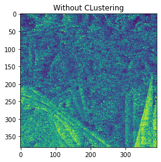

```python
plt.imshow(Dis_mat)
plt.title('Without Clustering');
```

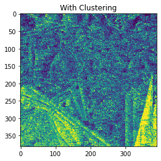

```python
plt.imshow(Dis_replace/np.max(Dis_replace))
plt.title('With Clustering');
```